# Programming Exercise 2: Logistic Regression

In this exercise, you will implement logistic regression and apply it to two different datasets.

## Logistic Regression

In this part of the exercise, you will build a logistic regression model to predict whether a student gets admitted into a university.

You have historical data from previous applicants that you can use as a training set for logistic regression. For each training example, you have the applicant’s scores on two exams and the admissions decision.

Your task is to build a classification model that estimates an applicant’s probability of admission based the scores from those two exams.

### Bring in data and assign X,y

```r
# remove all list
rm(list = ls())
library(ggplot2)
# BRING IN DATA
data1<-read.table("ex2data1.txt",sep=",",header = F)
colnames(data1)<-c('s1','s2','decision')
# number of training examples
head(data1)
```

|  | s1 | s2 | decision |
| --- | --- | --- | --- |
| 1 | 34.62366 | 78.02469 | 0 |
| 2 | 30.28671 | 43.89500 | 0 |
| 3 | 35.84741 | 72.90220 | 0 |
| 4 | 60.18260 | 86.30855 | 1 |
| 5 | 79.03274 | 75.34438 | 1 |
| 6 | 45.08328 | 56.31637 | 0 |

```r
X<-data1[,1:2]
y<-data1[,3]
m <- nrow(data1)
n<-ncol(X)
```

### Visualizing the data

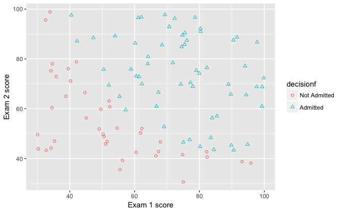

```r
# numeric to discrete factor for graphic
data1$decisionf<-factor(data1$decision,levels=c(0,1),labels=c('Not Admitted','Admitted'))
# Set color by cond
p<-ggplot(data1, aes(x=s1, y=s2, color=decisionf, shape=decisionf)) + geom_point()+scale_shape_manual(values=c(1,2))+
  xlab("Exam 1 score")+
  ylab("Exam 2 score")
p
```

### Sigmoid function

Recall that the logistic regres- sion hypothesis is defined as:
$$h_{\theta}(x)=g(\theta^Tx)$$
Where function g is the sigmoid function. The sigmoid function is defined as:

$$g(z)=\frac{1}{1+e^{-z}}$$

Define sigmoid function:

```r
# sigmoid function
sigmoid<-function(z){
  # %SIGMOID Compute sigmoid functoon
  # %   J = SIGMOID(z) computes the sigmoid of z.
  enez = exp(-z);
  g = 1/(1+enez);
  return(g)
}
```

Test on sigmoid function:

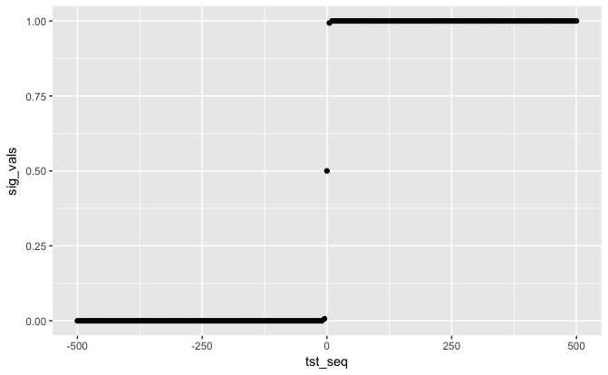

```r
tst_seq<-seq(-500,500,by=5)
# sigseq<-c()
for(i in 1:length(tst_seq)){
  sigval<-sigmoid(tst_seq[i])
  if(i==1){
    sigseq<-c(sigval)
  }else{sigseq<-rbind(sigseq,sigval)}
}
tstplot<-as.data.frame(cbind(tst_seq,sigseq))
colnames(tstplot)<-c("tst_seq","sig_vals")
ggplot(tstplot, aes(x=tst_seq, y=sig_vals)) + geom_point()
```

### Cost function and gradient

Recall that the cost function in logistic regression is
$$J(\theta)=\frac{1}{m} \sum\limits_{i=1}^{m}{[-y^{(i)}log(h_{\theta }(x^{(i)}))- (1-y^{(i)} )log(1-h_{\theta }(x^{(i)} ))]}$$
and the gradient of the cost is a vector of the same length as $\theta$ where the $j^{th}$ element (for j = 0,1,…,n) is defined as follows:
$$\frac{\partial J(\theta)}{\partial \theta_{j}}=\frac{1}{m}\sum\limits_{i=1}^{m}{(h_{\theta}(x^{(i)})-y^{(i)})x_{j}^{(i)}}$$
Note that while this gradient looks identical to the linear regression gra- dient, the formula is actually different because linear and logistic regression have different definitions of $h_{\theta }(x)$.

Construct cost function as:

```r
# Cost function and gradient
costFunction<-function(theta,X,y){
  # %COSTFUNCTION Compute cost and gradient for logistic regression
  # %   J = COSTFUNCTION(theta, X, y) computes the cost of using theta as the
  # %   parameter for logistic regression and the gradient of the cost
  # %   w.r.t. to the parameters.

  #  number of training examples
  m<-length(y)
  yhat<-sigmoid(X%*%theta)
  J<-(1/m)*sum(-y*log(yhat)-(1-y)*log(1-yhat))

  grad<-array(data=0,dim=c(dim(theta)))

  for(i in 1:length(theta)){
    grad[i]= (1/m)*sum((yhat-y)*X[,i])
  }
  results<- list("J"=J,"grad"=grad)
  return(results)
}
```

Compute initial cost and gradient on data:

```r
# Add intercept term to x
# % Add intercept term to X
ones<-array(data=1,dim=c(m,1))
X<-cbind(ones,X)
# convert X to matrix for matrix cal in functions
X<-as.matrix(X)
# % Initialize fitting parameters
initial_theta = array(data=0,dim=c(n+1,1))
# % Compute and display initial cost and gradient
cf.rs<-costFunction(initial_theta, X, y);
cost<-cf.rs$J
grad<-cf.rs$grad
```

Cost at initial theta (zeros): 0.6931472;

Gradient at initial theta (zeros): -0.1, -12.0092166, -11.2628422;

### Optimizing using `optim`

In the previous assignment, optimal parameters of a linear re- gression model was found by implementing gradent descent. We wrote a cost function and calculated its gradient, then took a gradient descent step accordingly.

In the original couse assignment, this oprimization was done using an Octave/- MATLAB built-in function called **fminunc**.

Octave/MATLAB’s **fminunc** is an optimization solver that finds the min- imum of an unconstrained function. For logistic regression, you want to optimize the cost function $J(θ)$ with parameters $θ$.

Now in **R**, we will try to use **optim**, a General-purpose Optimization function from *stats* package, to acomplish the same goal.

```r
optim(par, fn, gr = NULL, ...,
      method = c("Nelder-Mead", "BFGS", "CG", "L-BFGS-B", "SANN",
                 "Brent"),
      lower = -Inf, upper = Inf,
      control = list(), hessian = FALSE)
```

In Octave, fminunc is called as:

```r
%  Set options for fminunc
options = optimset('GradObj', 'on', 'MaxIter', 400);

%  Run fminunc to obtain the optimal theta
%  This function will return theta and the cost
[theta, cost] = ...
    fminunc(@(t)(costFunction(t, X, y)), initial_theta, options);
```

Now we use `optim` to mimic as:

```r
optim(par, fr, grr, method = "BFGS",control = list("maxit"=400))
```

Wrap cost function and gradient function seperately. `optim` function takes in `fr`~ cost function, and `grr` ~ gradient function. Start from data1, easier to apply to `optim` as parameters. multiple is also workable.

```r
# define fr and grr seperately from costFunction
fr_cost<-function(theta_v,data1){
  theta<-as.matrix(theta_v)
  X<-data1[,1:2]
  y<-data1[,3]
  m <- nrow(data1)
  n<-ncol(X)
  # % Add intercept term to X
  ones<-array(data=1,dim=c(m,1))
  X<-cbind(ones,X)
  # convert X to matrix for matrix cal in functions
  X<-as.matrix(X)

  cf.rs<-costFunction(theta, X, y);
  cost<-cf.rs$J
  return(cost)
}
grr_grad<-function(theta_v,data1){
  theta<-as.matrix(theta_v)
  X<-as.matrix(data1[,1:2])
  y<-data1[,3]
  m <- nrow(data1)
  n<-ncol(X)
  # % Add intercept term to X
  ones<-array(data=1,dim=c(m,1))
  X<-cbind(ones,X)
  # convert X to matrix for matrix cal in functions
  # X<-as.matrix(X)
  cf.rs<-costFunction(theta, X, y);
  grad<-cf.rs$grad
  return(grad)
}
```

Call optim functions

```r
op<-optim(par=c(0,0,0), fn=fr_cost, gr=grr_grad, data1=data1,
          method = "BFGS",control = list("maxit"=400))
```

Cost at theta found by `optim`: 0.2034986

theta:

-25.0839914, 0.205613, 0.2008458

#### Plot boundary

Add boundary line from logistic regression to the first plot:

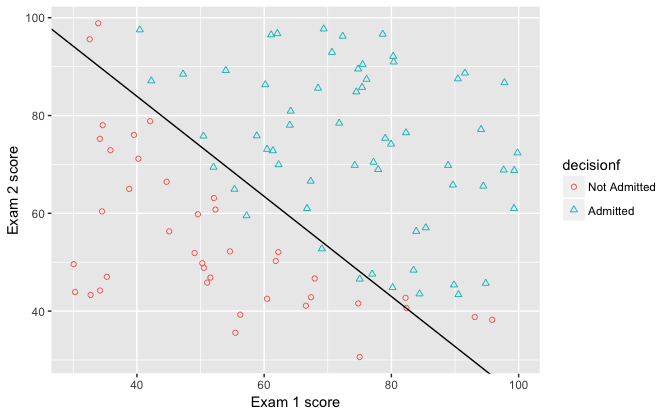

```r
# plot boundary
int<- - op$par[1]/op$par[3]
slp<- - op$par[2]/op$par[3]
p + geom_abline(intercept = int, slope = slp)
```